# Liverpool City Region: the SIA evidence base, then and now

A data report on the sources behind the 2017 and 2022 Science and Innovation Audits

Author

Claude Code (Anthropic’s AI agent)

Published

29 September 2026

**NoteMade by Claude Code, an AI agent**

This report, the analysis in it and the code that produces it were made by Claude Code, Anthropic’s AI coding agent (model: Claude Opus 5.5), in September 2026. The project lead set the task and made the main choices, such as which areas to compare LCR with. Claude Code did the work:

- **Read the audits.** Converted SIA1 (2017) and SIA2 (2022) from PDF to text, summarised them in a briefing note, and listed every data source they used.
- **Checked earlier claims.** Traced the “Advanced Manufacturing” figures in SIA1 back through the documents they came from, and tested them against official data.
- **Found the data.** Searched publishers’ websites and APIs for each source’s latest release. Where a source can’t be downloaded by script, it found alternatives, such as ONS high-growth enterprise tables in place of the Enterprise Research Centre’s dashboard. It also costed OpenAlex as an alternative to the SciVal bibliometrics SIA1 used.
- **Built a data pipeline in R.** Wrote code that checks for new releases and downloads each source. It keeps the original files, including the older release SIA2 used where its figures needed checking. It then turns them into consistent tables for every area of the UK.
- **Found and fixed data problems,** such as ONS’s suppression of West of England’s GVA, and code changes that had dropped Barnsley and Sheffield from South Yorkshire. Each is recorded in the code.
- **Checked the audits’ figures.** Recomputed 43 figures that SIA1 and SIA2 quoted, with their page references (Section 11).
- **Wrote the analysis and this report.** Chose the measures and comparisons, wrote the code for every chart and table, wrote the text, and produced this document with Quarto, checking the rendered pages.

Every number in the text is computed from the data when the report is built, not typed by hand. The work has not been independently reviewed, so check key figures before relying on them.

# Key messages

- **The evidence is much newer.** For the typical SIA evidence item, the data held now are 10 years newer than the data SIA1 used, and 4 years newer than the data SIA2 used (Section 2).
- **Productivity has fallen further behind.** LCR’s GVA per hour worked was 89.0% of the UK level in 2023, against 93.4% in 2011, and 7th of 15 among the combined authorities. Real GVA grew 20.5% from 2011 to 2024, against 25.6% for England (Section 5).
- **The “broadly flat” economy in SIA2 has been revised away.** Its figures reproduce exactly in the June 2021 release it used, but today’s release puts real growth from 2006 to 2019 at 10.5%, not 3.7% (Section 11).
- **Inactivity and ill health hold back employment.** The employment rate was 72.7% against 75.8% for England. 37.2% of LCR’s economically inactive residents are long-term sick, and 44.5% of its neighbourhoods are in England’s most deprived 10% for health deprivation and disability (Section 6, Section 8).
- **Deprivation remains high.** 28.8% of LCR’s neighbourhoods are in England’s most deprived 10% on the 2025 index, 2nd of 15 among the combined authorities (Section 8).
- **The business base is thin.** LCR has 430 enterprises per 10,000 working-age residents, 14th of 15. New firms are started at a higher rate than in England, but 47.6% survive three years, against 53.5% (Section 7).
- **Health dominates employment; advanced manufacturing is smaller than SIA1 said.** Health and social work is 19.6% of LCR’s jobs. On the Industrial Strategy definition, advanced manufacturing has 15,550 jobs; the 47,000 in SIA1 was all of manufacturing (Section 7).
- **R&D intensity is low.** Business R&D in Merseyside was 1.02% of GVA, 26th of 36 of the ITL2 regions with figures, against 2.14% for the UK. The SIA2 target of 5% of GVA covers all R&D, which isn’t published for LCR (Section 9).
- **One source is temporarily incomplete.** ONS suppressed GVA for West of England in its September 2026 release and expects to correct it within weeks; the pipeline will pick up the correction (Section 12).

Text checked against the data build of 29 September 2026.

# 1 About this report

**Working document.** This report supports the SIA3 bid and is not for publication. Its figures come from the data build of 29 September 2026, and every caption names the release of each source used.

## 1.1 Purpose

Liverpool City Region (LCR) has had two Science and Innovation Audits: SIA1, published in September 2017, and a refresh, SIA2, in 2022. SIA3 will refresh them again, as the evidence base for a new LCR Innovation Strategy due in June 2027.

This report goes through the public data sources that SIA1 and SIA2 used, and sets out what they show now. It has three aims:

- to show where LCR stands on the measures SIA1 and SIA2 used, against England and the other combined authorities;
- to show how the evidence has moved on since then, through newer releases, revisions and changed definitions;
- to state the source, release and definition of every figure, and to say plainly what the data can’t show.

It is a data report, not an assessment of LCR’s specialisms. It covers the measures that can be rebuilt from public data by script. Sources that can’t be, such as licensed bibliometrics or the audits’ own consultations, are listed in Section 12 and appendix A.

## 1.2 Liverpool City Region

LCR is the area of the Liverpool City Region Combined Authority. It is made up of six local authorities: Halton, Knowsley, Liverpool, Sefton, St Helens and Wirral. It is also the ITL2 region TLD7, “Merseyside”, so figures published for ITL2 regions cover exactly the same area.

## 1.3 Comparators

Charts show all 15 combined authorities in England, in three styles:

- **LCR**, in orange.
- **Established combined authorities**, in dark grey: the eight others with an elected mayor by 2021. They are Cambridgeshire and Peterborough, Greater Manchester, the North East, South Yorkshire, Tees Valley, West Midlands, West of England and West Yorkshire.
- **Newer combined authorities**, in light grey: the six set up in 2024 and 2025. They are Devon and Torbay, East Midlands, Greater Lincolnshire, Hull and East Yorkshire, Lancashire, and York and North Yorkshire.

The North East Combined Authority dates from 2024, but it counts as established through its predecessor, the North of Tyne Combined Authority, which had a mayor from 2019.

The national comparator is England where the source publishes it, and otherwise Great Britain or the UK. Ranks are among the 15 combined authorities, with 1 the highest value, whether or not a high value is good. Appendix B lists the authorities and their codes.

## 1.4 Reading the charts and tables

- **Captions** give each figure’s definition, any notes, and its sources with release dates.
- **Indices:** “UK = 100” means the area’s value as a percentage of the UK figure in the same year.
- **Periods** differ between measures, because each uses its source’s latest data.
- **Rounding:** some sources round their counts. BRES rounds to anything from the nearest 5 to the nearest 1,000 depending on size, and business counts to the nearest 5, so small differences mean little.

## 1.5 Abbreviations

Table 1: Abbreviations used in this report.

| Abbreviation | Meaning |
| --- | --- |
| APS | Annual Population Survey (ONS) |
| ASHE | Annual Survey of Hours and Earnings (ONS) |
| BERD | Business enterprise research and development |
| BRES | Business Register and Employment Survey (ONS) |
| CA | Combined authority |
| GDHI | Gross disposable household income |
| GERD | Gross domestic expenditure on research and development |
| GVA | Gross value added |
| IMD | Index of Multiple Deprivation |
| ITL | International Territorial Levels (UK statistical regions) |
| LSOA | Lower layer super output area (a neighbourhood of about 1,500 people) |
| REF | Research Excellence Framework |
| SIA | Science and Innovation Audit |
| SIC | Standard Industrial Classification (2007) |

# 2 The evidence base, then and now

The data pipeline behind this report keeps a register of 56 sources. It covers every source in the SIA1 and SIA2 evidence lists, plus replacements for sources that can’t be scripted and a few additions. Of these, 32 are downloaded and processed by script. The rest are manual downloads, licensed data, documents, or sources not yet built (Section 12).

Figure 1 shows, for each SIA evidence item the pipeline covers, the latest year of data SIA1 and SIA2 used and the latest year held now. For the typical item, the data held now are 10 years newer than the data SIA1 used, and 4 years newer than the data SIA2 used.

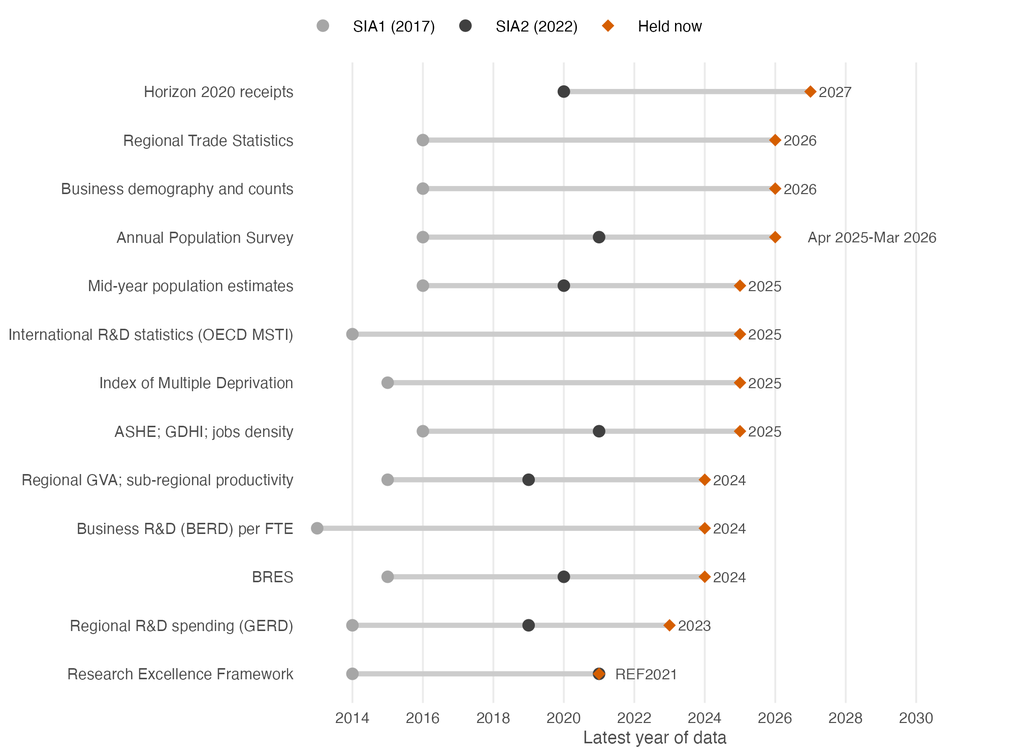

Figure 1: Latest year of data used by SIA1 and SIA2, and held now, by SIA evidence item. Latest data year used by SIA1 and by SIA2, and the latest held now, for each SIA evidence item. Source: the pipeline’s source register (R/source_register.csv) and update check (data/source_status.csv).

Table 2 shows how the register’s sources relate to the ones SIA1 and SIA2 used. Replacements stand in for sources that can’t be scripted: for example, OpenAlex for the SciVal bibliometrics SIA1 used, and ONS high-growth enterprise tables for the Enterprise Research Centre’s growth dashboard. Appendix A lists every source.

Table 2: Sources in the pipeline register, by their relation to SIA1 and SIA2.

| Role | Sources | Processed by script |
| --- | --- | --- |
| Used by SIA1 or SIA2 | 41 | 22 |
| Later edition of an SIA source | 3 | 3 |
| Related table from an SIA source | 2 | 2 |
| Replacement for an SIA source | 4 | 0 |
| Addition (not used by SIA1 or SIA2) | 5 | 4 |
| Geography lookup | 1 | 1 |

# 3 LCR at a glance

Figure 2 places LCR among the 15 combined authorities on 16 headline measures. Each row runs from the lowest combined authority to the highest; LCR is the orange dot, with its value and rank on the right, and the black tick marks England, Great Britain or the UK. LCR is in the top five on 2 measures and in the bottom five on 3.

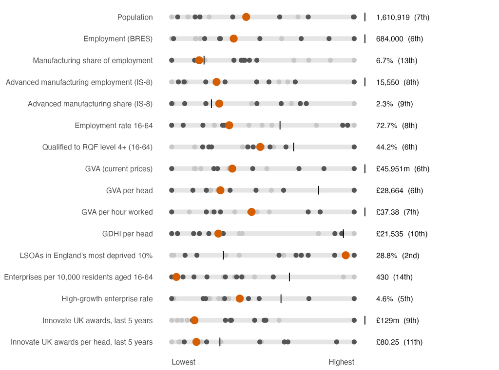

Figure 2: LCR among the 15 combined authorities on headline measures. Rank 1 = highest value among the 15 combined authorities, whether or not high is good. Source: ONS via Nomis, Population estimates (local authority based) (released 29 July 2026); ONS via Nomis, BRES open access (2015 on) (released 28 October 2025); ONS via Nomis, Annual Population Survey (variables) (released 21 July 2026); ONS, Regional GVA (balanced) by industry: local authorities (released 23 September 2026); ONS, Subregional productivity: local authorities (released 19 June 2025); ONS, Regional gross disposable household income: local authorities (released 19 August 2026); MHCLG, English Indices of Deprivation 2025 (released 17 November 2025); ONS via Nomis, UK Business Counts: enterprises (released 24 September 2026); ONS, Business demography (annual) (released 20 November 2025); UKRI, Innovate UK funded projects since 2004 (released 2 September 2026).

Table 3 gives the figures behind the chart, with each measure’s period. The measures are defined in appendix B.

Table 3: LCR’s value and rank on each headline measure, with the national comparator. Definitions are in appendix B; sources as for Figure 2.

| Measure | Period | LCR | Rank | National |
| --- | --- | --- | --- | --- |
| Population | 2025 | 1,610,919 | 7th of 15 | England 58,834,812 |
| Employment (BRES) | 2024 | 684,000 | 6th of 15 | England 28,412,000 |
| Manufacturing share of employment | 2024 | 6.7% | 13th of 15 | England 7.0% |
| Advanced manufacturing employment (IS-8) | 2024 | 15,550 | 8th of 15 | England 612,000 |
| Advanced manufacturing share (IS-8) | 2024 | 2.3% | 9th of 15 | England 2.2% |
| Employment rate 16-64 | Jan 2025-Dec 2025 | 72.7% | 8th of 15 | England 75.8% |
| Qualified to RQF level 4+ (16-64) | Jan 2025-Dec 2025 | 44.2% | 6th of 15 | England 48.0% |
| GVA (current prices) | 2024 | £45,951m | 6th of 14 | England £2,233,113m |
| GVA per head | 2024 | £28,664 | 6th of 14 | England £38,103 |
| GVA per hour worked | 2023 | £37.38 | 7th of 15 | England £42.51 |
| GDHI per head | 2024 | £21,535 | 10th of 15 | England £26,490 |
| LSOAs in England's most deprived 10% | 2025 | 28.8% | 2nd of 15 | England 10.0% |
| Enterprises per 10,000 residents aged 16-64 | 2026 (population 2025) | 430 | 14th of 15 | England 654 |
| High-growth enterprise rate | 2024 | 4.6% | 5th of 15 | England 5.0% |
| Innovate UK awards, last 5 years | 2021/22 to 2025/26 | £129m | 9th of 15 | England £8,352m |
| Innovate UK awards per head, last 5 years | 2021/22 to 2025/26 | £80.25 | 11th of 15 | England £142 |

Business R&D is published for ITL2 regions rather than combined authorities. On that measure Merseyside, which is the same area as LCR, ranks 26th of 36 of the UK’s ITL2 regions with published figures for business R&D as a share of GVA (Section 9).

# 4 People

LCR had 1,610,919 residents in mid-2025. Its population grew by 6.9% between 2011 and 2025, against 10.8% for England. That is 12th of 15 among the combined authorities (Figure 3).

SIA1 quoted 1.53 million people and SIA2 1.564 million in 2020. ONS revised its estimates for 2012 to 2020 after Census 2021, and the revised series puts LCR’s 2020 population lower (Section 11).

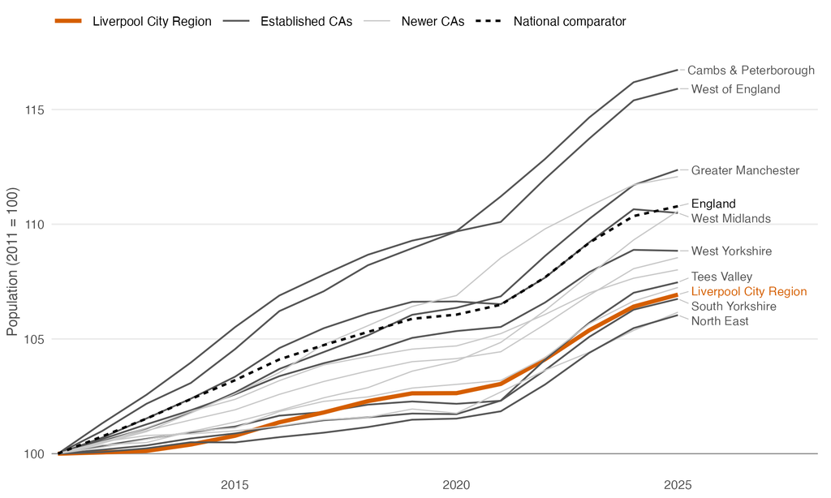

Figure 3: Population change since 2011 (2011 = 100). Mid-year population estimates, all ages. Index: 2011 = 100. Estimates for 2012-2020 were revised after Census 2021. Source: ONS via Nomis, Population estimates (local authority based) (released 29 July 2026).

LCR’s age structure is close to England’s. In mid-2025, 62.8% of residents were of working age (16 to 64), against 63.0% in England, and 19.8% were 65 or over, against 19.1% (Figure 4).

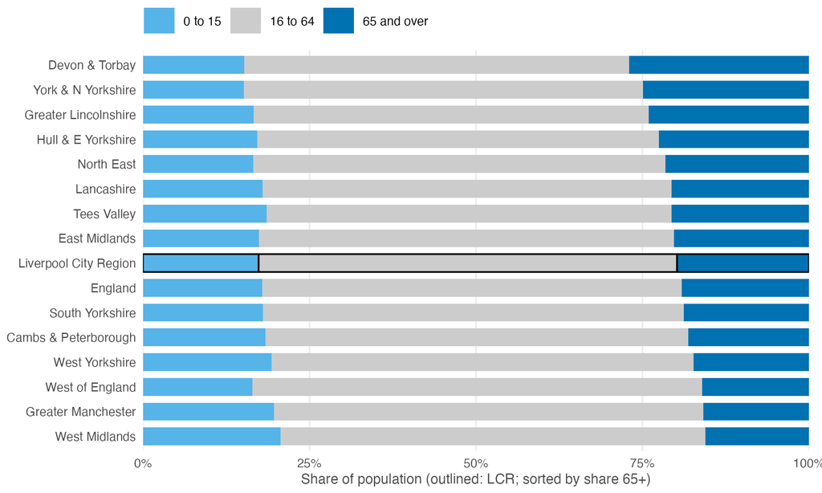

Figure 4: Population by broad age group, mid-2025. Share of the population in each broad age group, mid-2025. Source: ONS via Nomis, Population estimates (local authority based) (released 29 July 2026).

Table 4: Population by local authority. Mid-year population estimates, all ages. Source: ONS via Nomis, Population estimates (local authority based) (released 29 July 2026).

| Area | 2011 | 2021 | 2025 | Change since 2011 |
| --- | --- | --- | --- | --- |
| Halton | 125,722 | 128,570 | 131,912 | +4.9% |
| Knowsley | 145,903 | 154,978 | 163,723 | +12.2% |
| Liverpool | 465,656 | 485,022 | 507,915 | +9.1% |
| St. Helens | 175,405 | 183,394 | 189,890 | +8.3% |
| Sefton | 273,969 | 279,693 | 287,583 | +5.0% |
| Wirral | 319,837 | 320,631 | 329,896 | +3.1% |
| Liverpool City Region | 1,506,492 | 1,552,288 | 1,610,919 | +6.9% |
| England | 53,107,169 | 56,554,891 | 58,834,812 | +10.8% |

Text checked against the data build of 29 September 2026.

# 5 Economy and productivity

SIA1 and SIA2 described LCR’s economy through gross value added (GVA) and productivity. The headline in SIA2 was real GVA of £32.85bn in 2019, “just 3.7% above 2006” [SIA2 p.5-6]. This section updates those measures and shows how much revisions have changed the picture.

## 5.1 Output per head and per hour

GVA per head is distorted by commuting: GVA is counted where people work, but population where they live. GVA per hour worked avoids that, and ONS prefers it for comparing areas’ productivity. LCR’s GVA per hour was £37.38 in 2023, 89.0% of the UK level, having fallen from 93.4% in 2011 (Figure 6). It ranks 7th of 15 among the combined authorities.

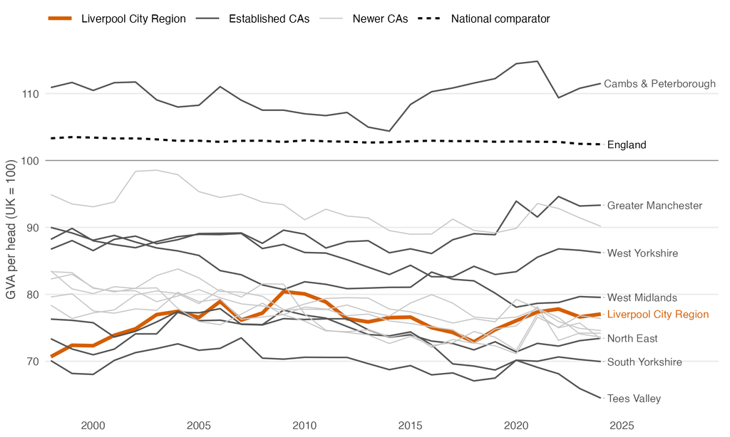

Figure 5: GVA per head as a percentage of the UK figure, 1998 onwards. Balanced GVA at current prices, summed from local authorities, divided by mid-year population. Index: UK = 100. No figures for West of England: ONS suppressed them after an error converting to the ITL 2025 regions. England and UK come from ONS’s ITL1 table. Source: ONS, Regional GVA (balanced) by industry: local authorities (released 23 September 2026); ONS via Nomis, Population estimates (local authority based) (released 29 July 2026).

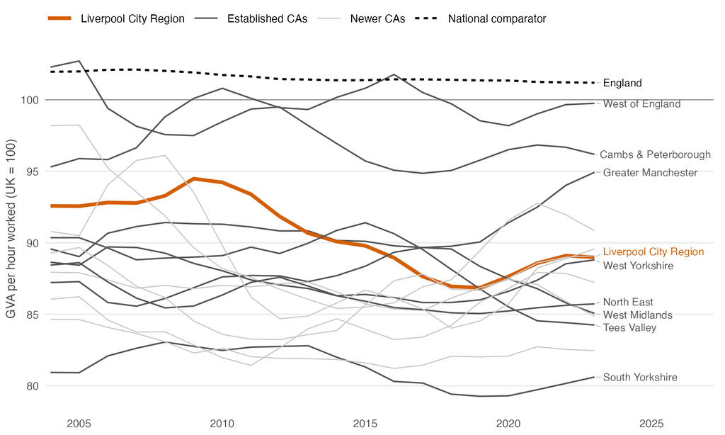

Figure 6: GVA per hour worked as a percentage of the UK figure, 2004 onwards. Smoothed current-price GVA per hour worked, hours-weighted across local authorities. Index: UK = 100. Source: ONS, Subregional productivity: local authorities (released 19 June 2025).

## 5.2 Real growth

In real terms, LCR’s GVA grew by 20.5% between 2011 and 2024, against 25.6% for England (Figure 7).

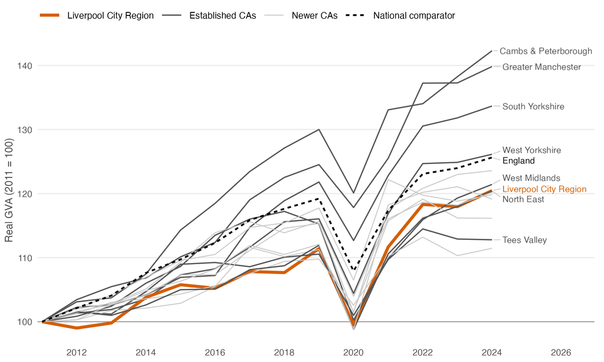

Figure 7: Real GVA growth since 2011 (2011 = 100). Balanced GVA in chained volume measures (2023 prices), summed from local authorities. Index: 2011 = 100. Chained volume measures are not strictly additive, so combined-authority totals are close approximations. No figures for West of England: ONS suppressed them after an error converting to the ITL 2025 regions. England and UK come from ONS’s ITL1 table. Source: ONS, Regional GVA (balanced) by industry: local authorities (released 23 September 2026).

## 5.3 The SIA2 GVA figure, revisited

SIA2 reported real GVA of £32.85bn in 2019 and described LCR’s economy as “broadly flat in real terms for more than a decade” [SIA2 p.5-6]. The June 2021 release of ONS’s regional GVA, held here as an original vintage, reproduces the SIA2 figure exactly: £32.85bn in 2018 prices, and growth of 3.7% since 2006.

Five years of revisions have changed that picture. Today’s release puts Merseyside’s real growth between 2006 and 2019 at 10.5%, rather than 3.7% (Figure 8). Current-price GVA for 2019 moved from £33.6bn to £34.6bn. On today’s figures, “broadly flat” no longer describes 2006 to 2019. Any SIA3 comparison with SIA2 figures should use one release for both years.

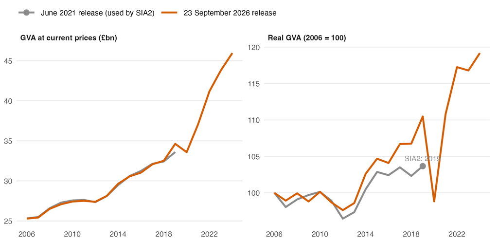

Figure 8: Merseyside GVA in the June 2021 release that SIA2 used and in today’s release. Merseyside (ITL2 TLD7), which is the same area as LCR. Balanced GVA, all industries. Source: ONS, Regional GVA (balanced) by industry: all ITL regions (released 11 June 2021, version 7; 23 September 2026).

## 5.4 Industry mix

Figure 9 compares the industry mix of Merseyside’s GVA with the UK’s in 2024. A location quotient above 1 means the industry makes up a larger share of Merseyside’s GVA than of the UK’s. The most over-represented is health and social work, at 15.2% of GVA against 8.5% for the UK. Manufacturing is 9.6% of Merseyside’s GVA, against 8.9% for the UK.

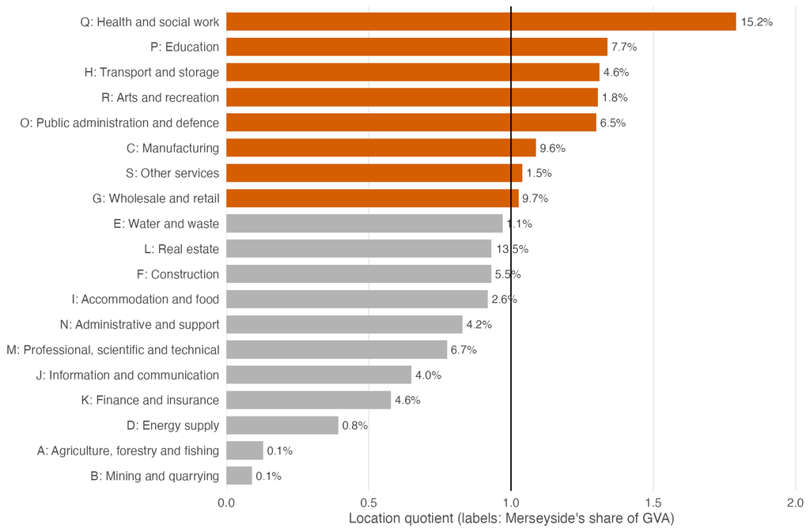

Figure 9: Industry mix of GVA, Merseyside against the UK, 2024. Share of GVA at current prices by SIC 2007 section, Merseyside (ITL2 TLD7) and UK. Location quotient = Merseyside share / UK share. Real estate (L) includes owner-occupiers’ imputed rent. Source: ONS, Regional GVA (balanced) by industry: all ITL regions (released 23 September 2026).

## 5.5 Local authorities

Figure 10 shows GVA per head in chained volume measures, which remove inflation, so the change between the two years is real change. Within LCR, GVA per head in 2024 ranged from £17,522 in St. Helens to £39,391 in Halton, at 2023 prices. Between 2015 and 2024, real GVA per head rose by 7.9% across LCR, against 7.1% for England. It fell in St. Helens, by 10.4%. Areas with more jobs than working residents look high on this measure, so it shows where output is produced rather than how well off residents are.

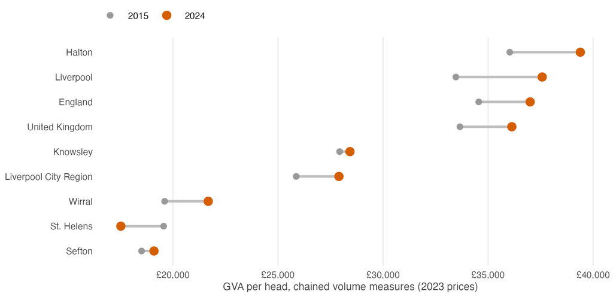

Figure 10: Real GVA per head by local authority, 2015 and 2024. Balanced GVA in chained volume measures (2023 prices) per resident, so the change between years is real change. LCR is summed from its local authorities, a close approximation since chained volume measures are not strictly additive. GVA is counted where people work, so areas with many in-commuters, such as Liverpool, look higher per resident. Source: ONS, Regional GVA (balanced) by industry: local authorities (released 23 September 2026); ONS via Nomis, Population estimates (local authority based) (released 29 July 2026).

## 5.6 Household income

Gross disposable household income (GDHI) measures what residents have to spend or save, so, unlike GVA, it is counted where people live. LCR’s GDHI per head was £21,535 in 2024, 82.9% of the UK figure and 10th of 15 among the combined authorities (Figure 11).

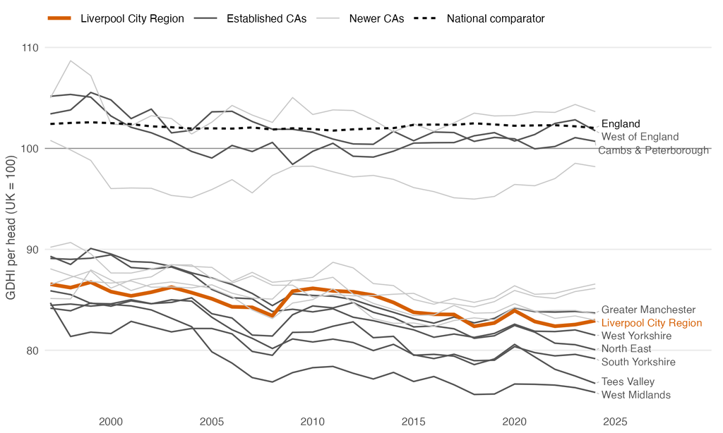

Figure 11: Household income (GDHI) per head as a percentage of the UK figure. Gross disposable household income, summed from local authorities, divided by the population in the same ONS tables. Index: UK = 100. Source: ONS, Regional gross disposable household income: local authorities (released 19 August 2026).

Text checked against the data build of 29 September 2026.

# 6 Jobs, skills and earnings

LCR’s employment rate for people aged 16 to 64 was 72.7% in 2025, against 75.8% for England. That gap of 3.1 points compares with 5.8 points in 2016, the year SIA1 quoted (Figure 12). The Annual Population Survey is a sample survey, so single-year changes for one area are uncertain: LCR’s 95% confidence interval is about ±1.7 points.

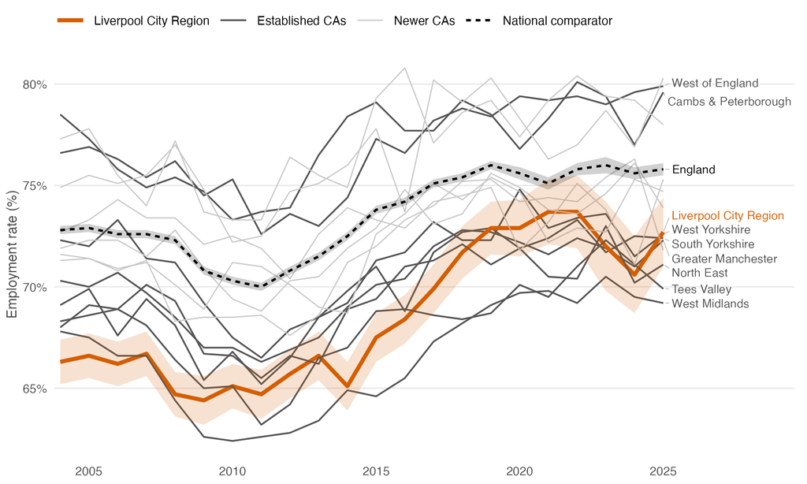

Figure 12: Employment rate, ages 16 to 64. Annual Population Survey, calendar years. Employed as % of people aged 16-64. Shaded bands are 95% confidence intervals published by Nomis. Source: ONS via Nomis, Annual Population Survey (variables) (released 21 July 2026).

The gap is mostly economic inactivity. In 2025, 23.5% of LCR’s working-age residents were economically inactive, against 20.5% in England, and 37.2% of LCR’s inactive residents were long-term sick, against 27.7% (Figure 13).

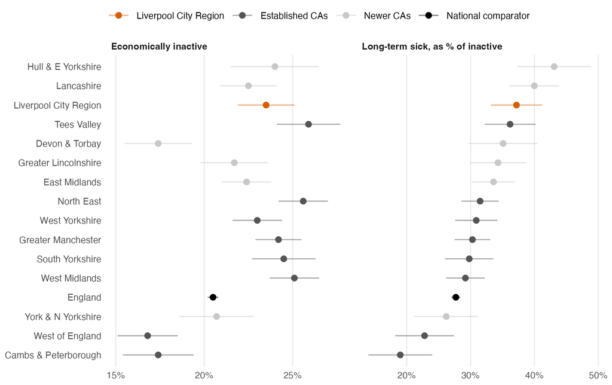

Figure 13: Economic inactivity and long-term sickness. Annual Population Survey, calendar years. Economically inactive as % of people aged 16-64; long- term sick as % of the inactive. Source: ONS via Nomis, Annual Population Survey (variables) (released 21 July 2026).

Skills have improved. On the old NVQ measure, 39.4% of LCR’s working-age residents were qualified to level 4 or above in 2021 (England 43.2%), up from 31.9% in 2016. On the RQF measure used since 2022, the figure was 44.2% in 2025, against 48.0% for England (Figure 14). The two measures aren’t directly comparable.

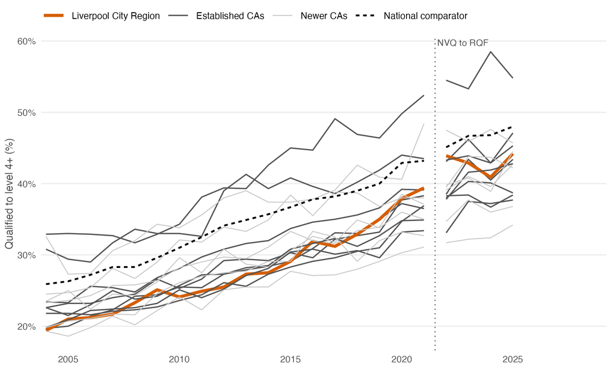

Figure 14: Qualified to level 4 or above, ages 16 to 64. Annual Population Survey, calendar years. Share of people aged 16-64 qualified to level 4 or above (degree level or equivalent). Qualifications moved from NVQ to RQF levels in 2022, so the series break there. Source: ONS via Nomis, Annual Population Survey (variables) (released 21 July 2026).

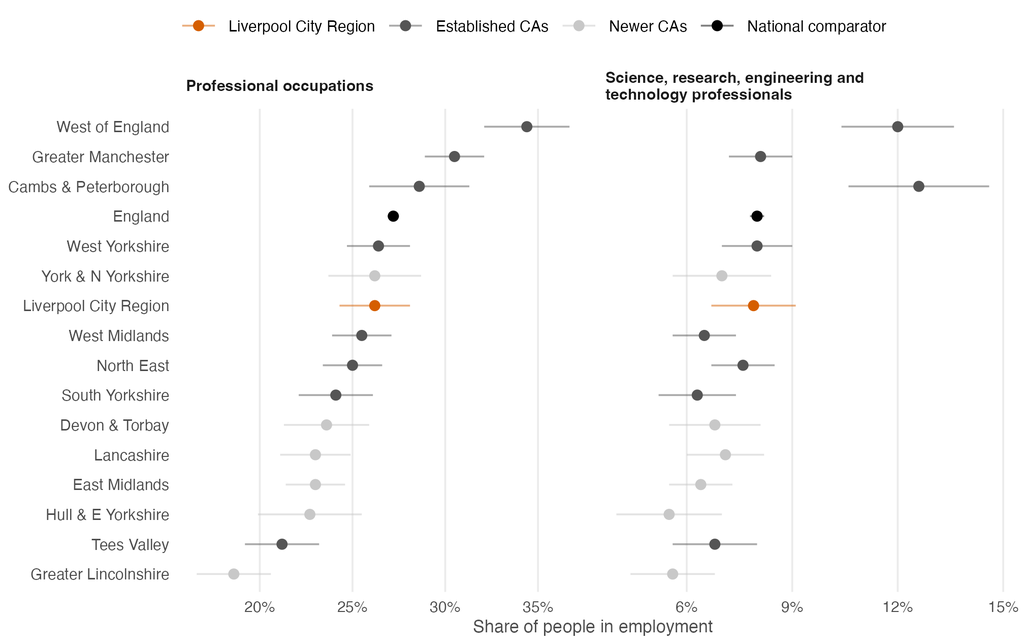

Figure 15: Employment in professional occupations. Annual Population Survey, calendar years. Share of people in employment, by occupation (SOC 2020). Source: ONS via Nomis, Annual Population Survey (variables) (released 21 July 2026).

## 6.1 Earnings

Earnings are published only for local authorities, not combined authorities, and medians can’t be added up, so Figure 16 shows LCR’s six local authorities. It gives median weekly pay of full-time employees both where they work and where they live. In 2025, pay by workplace ranged from £647 in St. Helens to £838 in Knowsley, against £767 for Great Britain. Local figures have wide margins of error: ONS treats a coefficient of variation above 20% as unreliable.

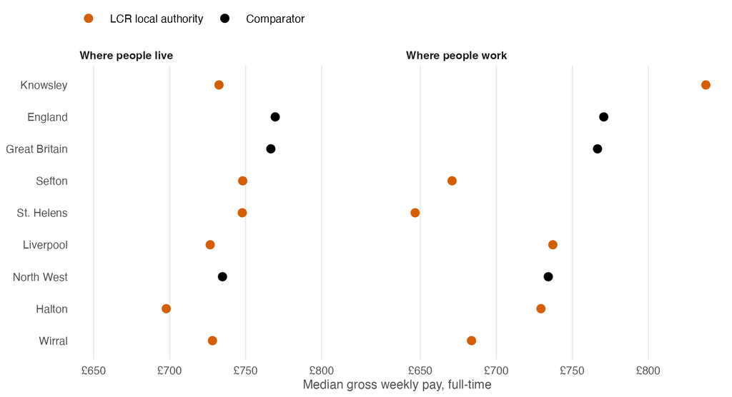

Figure 16: Median weekly pay of full-time employees by local authority, 2025. Median gross weekly pay of full-time employees (ASHE), by where they work and where they live. No combined-authority figure exists: Nomis publishes ASHE only down to local authorities, and medians can’t be added up. Source: ONS via Nomis, ASHE workplace analysis (released 3 November 2025); ONS via Nomis, ASHE resident analysis (released 3 November 2025).

## 6.2 Jobs density

Jobs density is the number of jobs per resident aged 16 to 64. LCR’s was 0.74 in 2024, against 0.86 for England (Figure 17). Within LCR it ranged from 0.60 in Sefton to 0.92 in Liverpool, which reflects commuting into Liverpool and Halton.

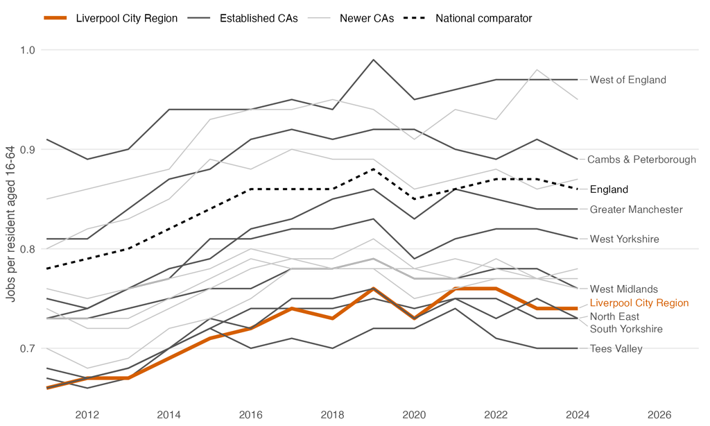

Figure 17: Jobs density. Jobs density: total jobs per resident aged 16-64. Source: ONS via Nomis, Jobs density (released 21 April 2026).

Text checked against the data build of 29 September 2026.

# 7 Business base and sectors

This section uses the Business Register and Employment Survey (BRES) for employment by industry, UK Business Counts for firms by size, and ONS business demography for firm births, deaths and survival.

## 7.1 Industry structure

Figure 18 compares LCR’s employment by industry with Great Britain’s in 2024. LCR has a larger share than Great Britain in public administration and defence, health and social work, transport and storage. Public administration and defence makes up 6.7% of LCR’s employment, against 4.7% for Great Britain. Health and social work alone is 19.6% of LCR’s jobs.

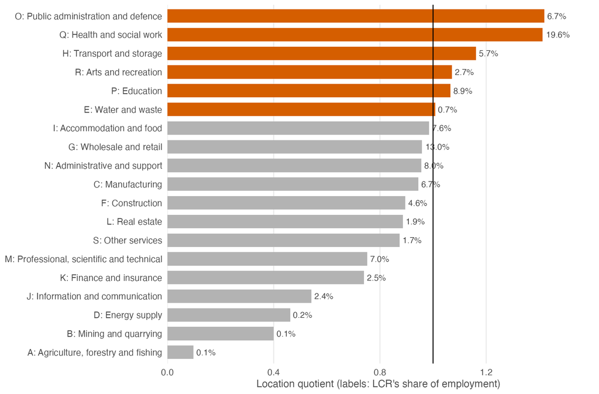

Figure 18: Employment by industry, LCR against Great Britain, 2024. Employment by SIC 2007 section, share of all employment, LCR and Great Britain. Location quotient = LCR share / GB share. BRES is rounded and covers Great Britain only; 2024 figures are provisional. Source: ONS via Nomis, BRES open access (2015 on) (released 28 October 2025).

Between 2015 and 2024, the largest growth was in human health activities (+27,000 jobs) and the largest fall in retail trade, except of motor vehicles and motorcycles (-9,000) (Figure 19). Combined-authority figures from BRES are rounded, often to the nearest thousand, so small changes can’t be read from them.

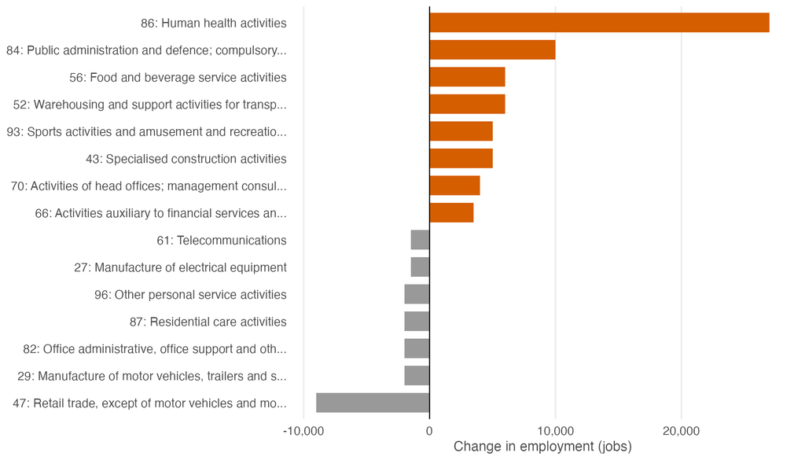

Figure 19: Largest changes in LCR employment by industry division, 2015 to 2024. Change in LCR employment by SIC 2007 division, 2015 to 2024 . BRES is rounded and covers Great Britain only; 2024 figures are provisional. Source: ONS via Nomis, BRES open access (2015 on) (released 28 October 2025).

## 7.2 Advanced manufacturing: which definition?

The growth-sector table in SIA1 gave Advanced Manufacturing 47,000 jobs in 2015. That turns out to be all of manufacturing (Section 11). Figure 20 shows LCR’s manufacturing employment on three definitions:

- all manufacturing (SIC 10-33);
- a whole-division approximation of Eurostat’s high and medium-high technology manufacturing (SIC 20, 21 and 26-30);
- the Industrial Strategy’s advanced manufacturing sector (IS-8: SIC 20 and 26-30, which leaves pharmaceuticals to Life Sciences).

On the IS-8 definition, LCR had 19,500 jobs in 2015 and 15,550 in 2024, against 47,975 and 46,015 in all manufacturing.

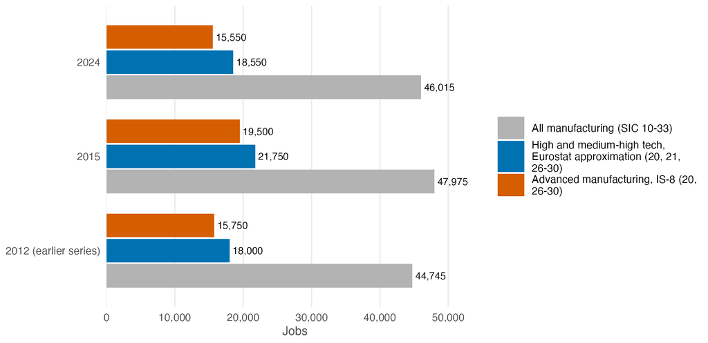

Figure 20: LCR manufacturing employment on three definitions. LCR employment in manufacturing on three definitions, by SIC 2007 division. The 2009-14 series excludes PAYE-only units, so 2012 isn’t directly comparable with 2015 on. BRES is rounded and covers Great Britain only; 2024 figures are provisional. Source: ONS via Nomis, BRES open access (2015 on) (released 28 October 2025); ONS via Nomis, BRES 2009-2015 (excluding PAYE-only units) (released 28 September 2016).

## 7.3 Firms

LCR’s business base is slightly less dominated by micro firms than Great Britain’s: 87.8% of its enterprises employ fewer than 10 people, against 89.1% (Figure 21). It has fewer firms per head, though: 430 enterprises per 10,000 residents aged 16 to 64, which ranks it near the bottom of the combined authorities (Section 3).

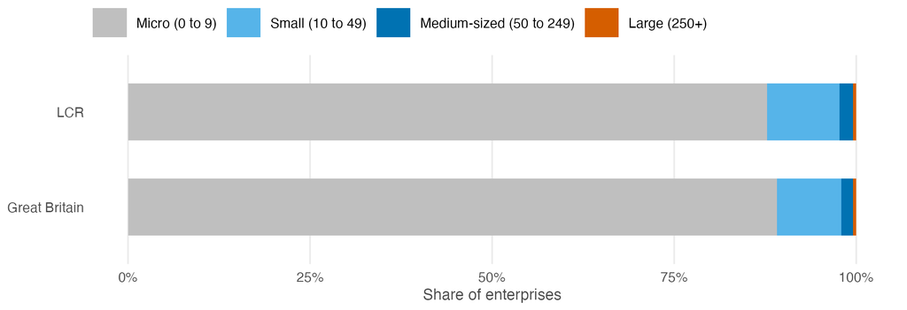

Figure 21: Enterprises by size band. Enterprises by employment size band, share of all enterprises, LCR and Great Britain (UK Business Counts, March). Source: ONS via Nomis, UK Business Counts: enterprises (released 24 September 2026).

Firm turnover is higher in LCR than in England. In 2024 there were 12.7 births and 11.4 deaths per 100 active enterprises, against 11.2 and 9.9 for England (Figure 22). Survival is lower: 47.6% of LCR enterprises born in 2021 were still active three years later, against 53.5% in England (Figure 23).

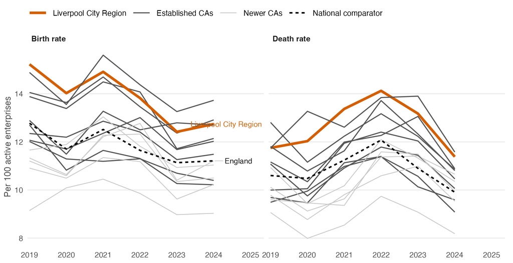

Figure 22: Enterprise birth and death rates. Enterprise births and deaths per 100 active enterprises, summed from local authorities. Source: ONS, Business demography (annual) (released 20 November 2025).

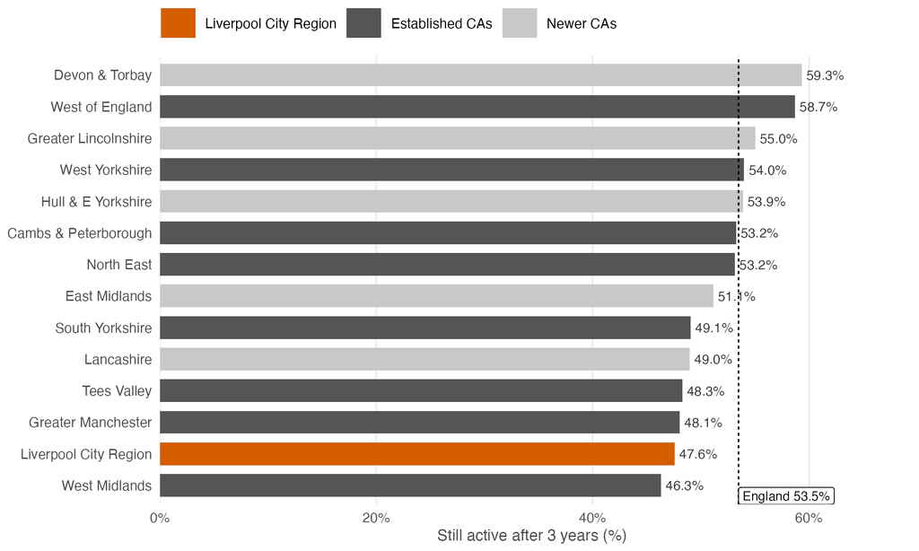

Figure 23: Three-year survival of new enterprises. Share of enterprises born in each year still active three years later, rebuilt from local authority counts. Source: ONS, Business demography (annual) (released 20 November 2025).

Text checked against the data build of 29 September 2026.

# 8 Deprivation

The English Indices of Deprivation rank every neighbourhood (LSOA) in England. SIA1 used the 2015 edition, and the latest is 2025.

28.8% of LCR’s 1,003 neighbourhoods are in England’s most deprived 10% on the 2025 Index of Multiple Deprivation (IMD), 2nd of 15 among the combined authorities (Figure 24). By construction, 10% of England’s neighbourhoods are in that group.

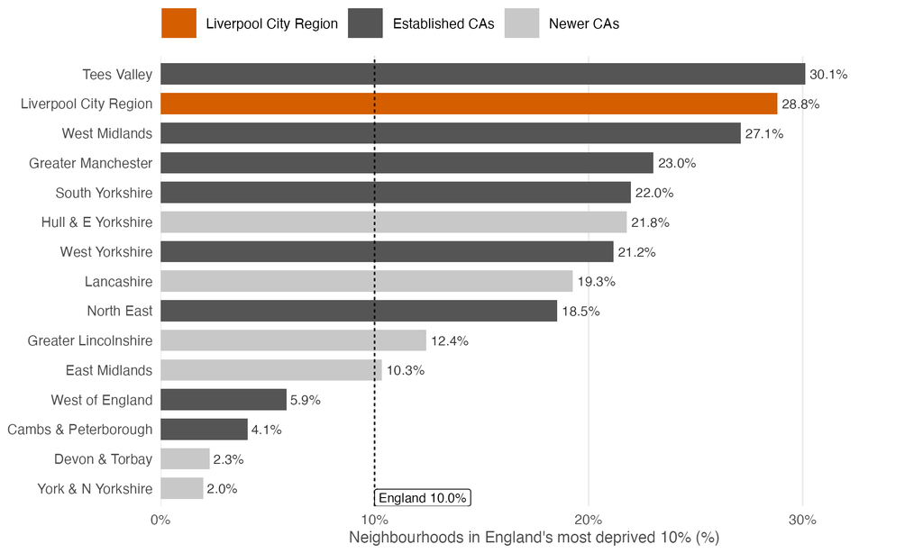

Figure 24: Share of neighbourhoods in England’s most deprived 10%, IMD 2025. Share of each combined authority’s neighbourhoods (2021 LSOAs) in England’s most deprived 10% and 20% on the Index of Multiple Deprivation 2025. Source: MHCLG, English Indices of Deprivation 2025 (released 17 November 2025).

Within LCR the share ranges from 18.8% in Sefton to 40.0% in Knowsley (Figure 25).

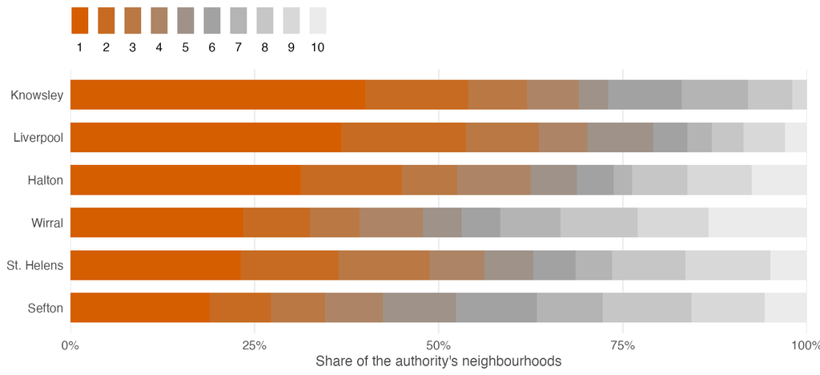

Figure 25: LCR neighbourhoods by national deprivation decile, IMD 2025. LCR neighbourhoods (2021 LSOAs) by national IMD 2025 decile (1 = most deprived 10%). Source: MHCLG, English Indices of Deprivation 2025 (released 17 November 2025).

The IMD combines seven domains. LCR’s most deprived domains are health deprivation and disability, with 44.5% of its neighbourhoods in England’s most deprived 10%, and employment (33.2%) (Figure 26). Both bear directly on the labour-market figures in Section 6.

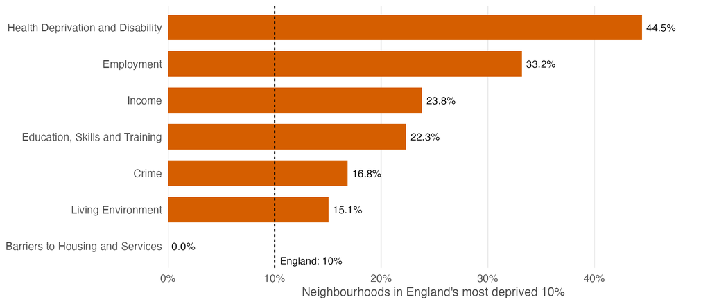

Figure 26: Share of LCR neighbourhoods in England’s most deprived 10%, by domain. Share of LCR neighbourhoods in England’s most deprived 10% on each domain of the IoD 2025. Source: MHCLG, English Indices of Deprivation 2025 (released 17 November 2025).

Table 5 compares LCR’s local authorities across the three editions. Deprivation ranks are relative, so an area can move without changing itself. The 2025 edition also uses the 2021 neighbourhood boundaries and ranks fewer local authorities (296, against 326 in 2015), after local government reorganisation. Changes in rank should be read with that in mind.

Table 5: LCR local authorities in the 2015, 2019 and 2025 Indices of Deprivation. Local authority summaries: share of LSOAs in England’s most deprived 10%, and rank of average score among all English local authorities (1 = most deprived). Ranks are relative, and 2025 uses 2021 LSOAs where earlier editions used 2011 ones. Source: DCLG, English Indices of Deprivation 2015 (SIA1 vintage) (released 30 September 2015); MHCLG, English Indices of Deprivation 2019 (released 26 September 2019); MHCLG, English Indices of Deprivation 2025 (released 17 November 2025).

| Local authority | Edition | Rank of average score | Share in most deprived 10% |
| --- | --- | --- | --- |
| Halton | 2015 | 27 of 326 | 26.6% |
| Halton | 2019 | 23 of 317 | 31.6% |
| Halton | 2025 | 31 of 296 | 31.2% |
| Knowsley | 2015 | 2 of 326 | 45.9% |
| Knowsley | 2019 | 2 of 317 | 46.9% |
| Knowsley | 2025 | 13 of 296 | 40.0% |
| Liverpool | 2015 | 4 of 326 | 45.0% |
| Liverpool | 2019 | 3 of 317 | 48.7% |
| Liverpool | 2025 | 9 of 296 | 36.8% |
| Sefton | 2015 | 76 of 326 | 20.1% |
| Sefton | 2019 | 58 of 317 | 20.1% |
| Sefton | 2025 | 80 of 296 | 18.9% |
| St. Helens | 2015 | 36 of 326 | 23.5% |
| St. Helens | 2019 | 26 of 317 | 24.4% |
| St. Helens | 2025 | 46 of 296 | 23.1% |
| Wirral | 2015 | 66 of 326 | 21.4% |
| Wirral | 2019 | 42 of 317 | 25.2% |
| Wirral | 2025 | 58 of 296 | 23.4% |

Text checked against the data build of 29 September 2026.

# 9 Research and innovation

SIA1 judged research excellence mainly through REF 2014 and SciVal bibliometrics, and SIA2 through REF 2021. This section covers the REF, R&D spending, EU framework funding and Innovate UK awards. Bibliometrics would need OpenAlex, which isn’t pulled yet (see the worklog).

## 9.1 Research Excellence Framework

REF 2021 is still the latest exercise; the next reports in 2029. Figure 27 shows each LCR university submission’s overall grade point average (GPA) against the spread of all UK submissions to the same unit of assessment. 20 of the 67 LCR submissions score above the UK median for their unit.

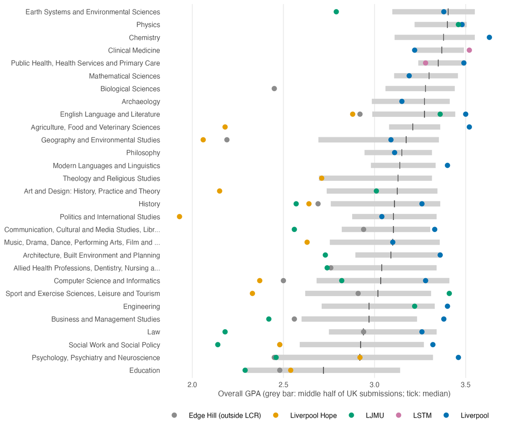

Figure 27: REF 2021: LCR universities’ overall GPA by unit of assessment. Overall grade point average (GPA) of each LCR university submission to REF 2021, against the median and interquartile range of all UK submissions to the same unit of assessment. GPA = (4 x %4* + 3 x %3* + 2 x %2* + %1*) / 100. Edge Hill (Ormskirk) is just outside LCR. Source: UKRI (Research England), REF 2021 results (REF2021).

Table 6 sets REF 2014 against REF 2021 for each institution. The University of Liverpool’s FTE-weighted GPA was 3.34 in 2021, 31st of 157 among UK institutions, and its research power ranked 19th. Units of assessment changed between the exercises, and published league tables rank slightly different sets of institutions, so ranks here won’t always match them (Section 11).

Table 6: REF 2014 and REF 2021 by institution. FTE-weighted overall GPA and research power (GPA x FTE staff) by institution, with ranks among all UK institutions in each exercise. Units of assessment changed between 2014 (36) and 2021 (34). Source: HEFCE, REF 2014 results (SIA1 vintage) (REF2014); UKRI (Research England), REF 2021 results (REF2021).

| Institution | REF | FTE staff | GPA | GPA rank | Research power rank |
| --- | --- | --- | --- | --- | --- |
| Edge Hill University | 2014 | 138 | 2.22 | 129th of 154 | 94th of 154 |
| Edge Hill University | 2021 | 259 | 2.67 | 117th of 157 | 84th of 157 |
| Liverpool Hope University | 2014 | 112 | 2.21 | 130th of 154 | 100th of 154 |
| Liverpool Hope University | 2021 | 168 | 2.52 | 129th of 157 | 99th of 157 |
| Liverpool John Moores University | 2014 | 243 | 2.79 | 75th of 154 | 62nd of 154 |
| Liverpool John Moores University | 2021 | 584 | 2.82 | 98th of 157 | 46th of 157 |
| Liverpool School of Tropical Medicine | 2014 | 35 | 3.10 | 30th of 154 | 121st of 154 |
| Liverpool School of Tropical Medicine | 2021 | 82 | 3.44 | 15th of 157 | 115th of 157 |
| University of Liverpool | 2014 | 760 | 3.06 | 41st of 154 | 19th of 154 |
| University of Liverpool | 2021 | 1,225 | 3.34 | 31st of 157 | 19th of 157 |

## 9.2 R&D spending

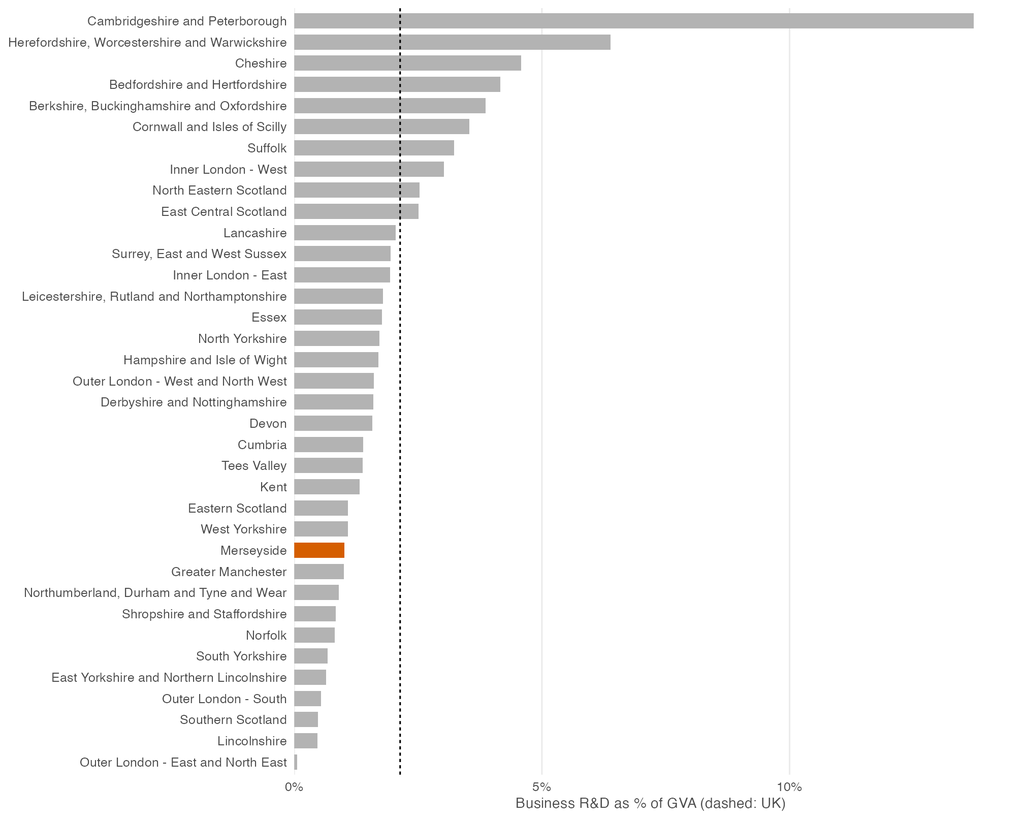

Figure 28: Business R&D as a share of GVA, ITL2 regions. Business enterprise R&D by ITL2 region (ITL 2025), in £ million and as % of GVA at current prices. Regions whose GVA ONS suppressed in the September 2026 release have no percentage. Source: ONS, BERD (official statistics) (released 28 November 2025).

Total R&D spending (GERD) is published only for regions. In 2023, the North West’s GERD was £6,105m, 8.4% of the UK total and 2.50% of its GVA (Figure 29). ONS suppresses some regions’ totals.

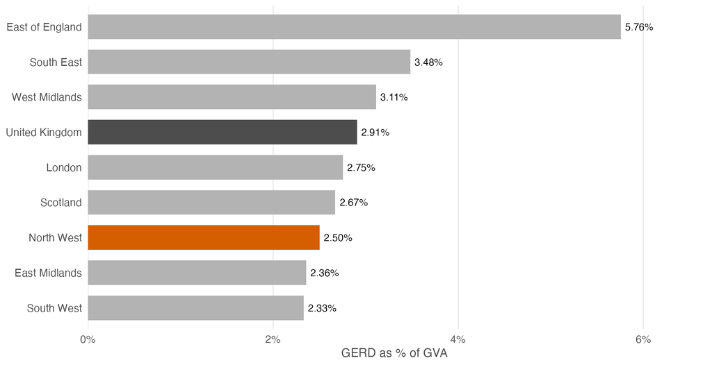

Figure 29: R&D spending (GERD) as a share of GVA, by region, 2023. Gross domestic expenditure on R&D by region, by sector performing it, and as % of GVA at current prices. Some regions’ figures are suppressed by ONS. Source: ONS, GERD (official statistics) (released 15 August 2025); ONS, Regional GVA (balanced) by industry: all ITL regions (released 23 September 2026).

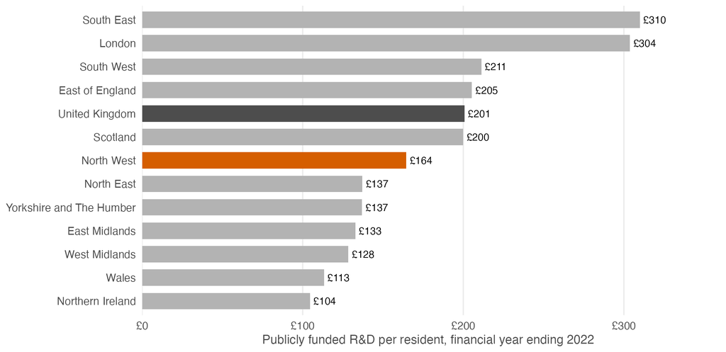

Figure 30: Publicly funded R&D per resident, by region. Publicly funded R&D by region (performed in house or purchased), financial year ending 2022, total and per resident. Source: ONS, Public-funded regional R&D spending (released 25 June 2024); ONS via Nomis, Population estimates (local authority based) (released 29 July 2026).

Internationally, the UK spent 2.75% of GDP on R&D in 2023, against 2.70% for the OECD as a whole (Figure 31).

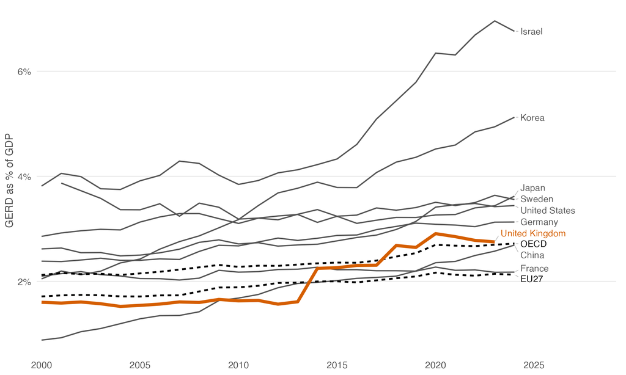

Figure 31: R&D spending as a share of GDP, selected countries. Gross domestic expenditure on R&D as % of GDP. Source: OECD, OECD Main Science and Technology Indicators (released 19 June 2026).